# Capstone Project

Bryan Aguiar

Monday, March 23, 2015

```r
# Clear
rm(list=ls())

# Turn off scientific notations for numbers
options(scipen = 999)

# Set locale
Sys.setlocale("LC_ALL", "English")
```

```
## [1] "LC_COLLATE=English_United States.1252;LC_CTYPE=English_United States.1252;LC_MONETARY=English_United States.1252;LC_NUMERIC=C;LC_TIME=English_United States.1252"
```

```r
# Set seed for reproducibility
set.seed(2345)

# Set the working directory and load the needed libraries
setwd("G:/DataCapstone")
library(tm)
library(RWeka)
library("SnowballC")
library("wordcloud")
library("RColorBrewer")

# Function to subsample the large text files
subsamfile <- function(infile,outfile,k,header=T) {
  ci <- file(infile,"r")
  co <- file(outfile,"w")
  if (header) {
    hdr <- readLines(ci,n=1)
    writeLines(hdr,co)
  }
  recnum = 0
  numout = 0
  while (TRUE) {
    inrec <- readLines(ci,n=1)
    if (length(inrec) == 0) {  # end of file?
      close(co)
      return(numout)
    }
    recnum <- recnum + 1
    if (recnum %% k == 0) {
      numout <- numout + 1
      writeLines(inrec,co)
    }
  }
}

# Function to count lines in a text file
linecount <- function(infile) {
  testconn <- file(infile, open="r")
  csize <- 10000
  nolines <- 0
  while((readnlines <- length(readLines(testconn,csize))) >0 )
    nolines <- nolines+readnlines
  close(testconn)
  return(nolines)
}

# Functions to build n grams
BigramTokenizer <- function(x) NGramTokenizer(x, Weka_control(min = 2, max = 2))
TrigramTokenizer <- function(x) NGramTokenizer(x, Weka_control(min = 3, max = 3))

# Function to convert tdms to data frame
dfit <- function (file){
  m <- as.matrix(file)
  v <- sort(rowSums(m),decreasing=TRUE)
  df <- data.frame(word = names(v),freq=v)
  head(df, 10)
  return (df)
}

# Function to make a Top 10 Barchart
barit <-function(df){
barplot(df[1:10,]$freq, las = 2, names.arg = df[1:10,]$word,
        col ="lightblue", main ="10 Frequent Words",
        ylab = "Word Frequencies")
}

# Function to make a wordcloud
wordit <- function(df) {
  wordcloud(words = df$word, freq = df$freq, min.freq = 1,
          max.words=200, random.order=FALSE, rot.per=0.35,
          colors=brewer.pal(8, "Dark2"))
}

#Count lines
blogslinecnt <- linecount("en_US.blogs.txt")
newslinecnt <-linecount("en_US.news.txt")
twitterlinecnt <-linecount("en_US.twitter.txt")
```

## Introduction

The purpose of this capstone project is to predict a successive word after a word is typed by the user. The final product will be a web application that allows a user to input text into a text field. The application will predict what words comes next and display a few words that are predicted. The user can click on these words for faster user input if the words are correctly predicted or continue to type. As the user continues to input characters the application will continue to display predicted words on the sequence of character inputs.

## Data Acquisition

```r
# Subset the data. This only needs to be run 1 time for each file
#nbr = 100 # 1% of the records
#subsamfile("en_US.news.txt","newsout.txt",nbr)
#subsamfile("en_US.blogs.txt","blogout.txt",nbr)
#subsamfile("en_US.twitter.txt","twitterout.txt",nbr)

# Create the trainingset
txt <- paste(readLines("G:/DataCapstone/newsout.txt"),readLines("G:/DataCapstone/twitterout.txt"),readLines("G:/DataCapstone/blogout.txt"))
```

## Data Cleaning

The training set was converted to a corpus using the tm package. The corpus was clean to remove punctuation, to remove numbers, to convert to lower case, and to strip white spaces. Next, stop words were removed from the corpus. Finally, a file containing profanity was loaded and words in the file were removed from the corpus.

```r
# Create a corpus
corpus <- Corpus(VectorSource(txt))
#save ("txt", file="txt.Rdata")
#save ("corpus", file="corpus.Rdata")
rm(txt)

# Clean the corpus
toSpace <- content_transformer(function(x, pattern) gsub(pattern, " ", x))
corpus <- tm_map(corpus, content_transformer(tolower))
corpus <- tm_map(corpus, removeNumbers)
corpus <- tm_map(corpus, removeWords, stopwords("english"))
corpus <- tm_map(corpus, removePunctuation)
corpus <- tm_map(corpus, stripWhitespace)
corpus <- tm_map(corpus, toSpace, "@")
#corpus <- tm_map(corpus, content_transformer(stemDocument))

# remove profanity
badwords <- readLines('G:/DataCapstone/badwords.txt')
corpus <- tm_map(corpus, removeWords, badwords)
```

The corpus was converted into Term Document Matrices using the tm package. Bigram and Trigram TDMs were created. Next, sparse words were removed from all the TDMs using threshold values varying of at least .99.

```r
# create a tdm
tdm <- TermDocumentMatrix(corpus)
dtm <- DocumentTermMatrix(corpus)
#save ("tdm", file ="tdm.Rdata")
#save ("dtm", file ="dtm.Rdata")

# Create N grams
bigram <- TermDocumentMatrix(corpus, control = list(tokenize = BigramTokenizer))
#save ("bigram",file="bigram.Rdata")
trigram <- TermDocumentMatrix(corpus, control = list(tokenize = TrigramTokenizer))
#save ("trigram",file="trigram.Rdata")

# remove the corpus
rm(corpus)

# remove sparse terms
tdm <- removeSparseTerms(tdm, sparse=0.99)
dtm <- removeSparseTerms(dtm, sparse=0.99)
bigram <- removeSparseTerms(bigram, sparse=0.998)
trigram <- removeSparseTerms(trigram, sparse=0.9986)
```

## Graphical Respresentations

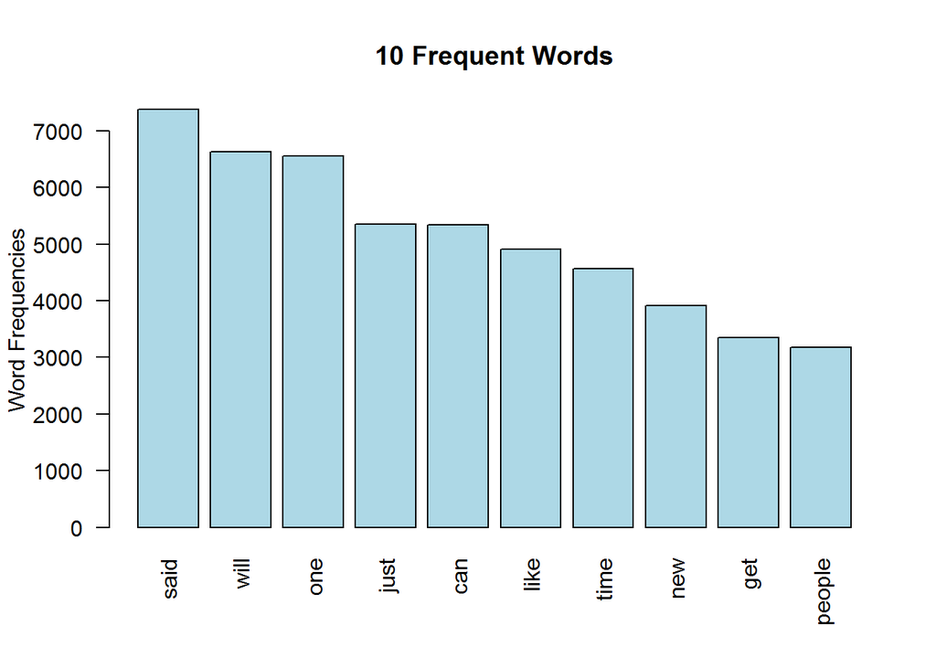

```r
# Counts
#rowSums(as.matrix(tdm))
#colSums(as.matrix(dtm))
#rowSums(as.matrix(bigram))
#rowSums(as.matrix(trigram))

# Convert to dataframe and make barchart and words cloud
df <-dfit(tdm)
barit(df)
```

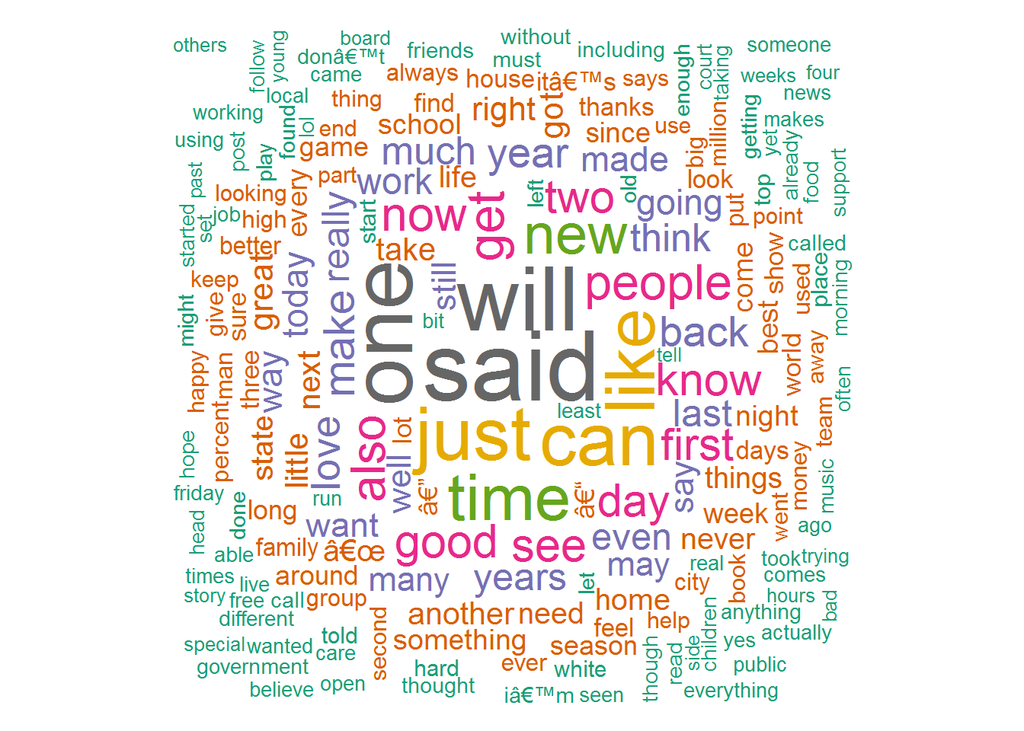

```r
wordit(df)
```

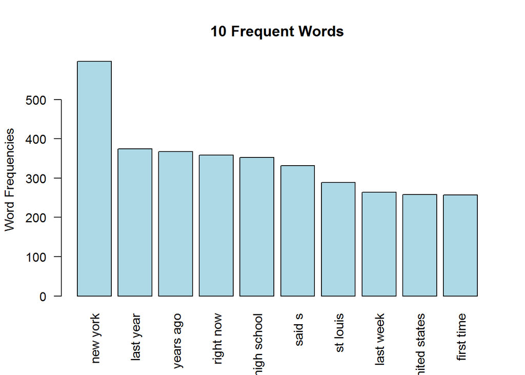

```r
df <-dfit(bigram)
barit(df)
```

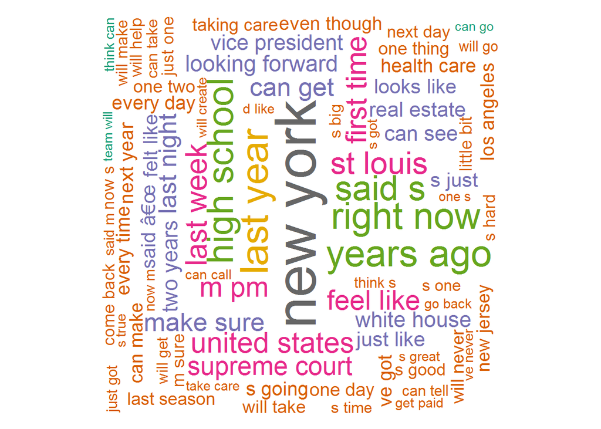

```r
wordit(df)
```

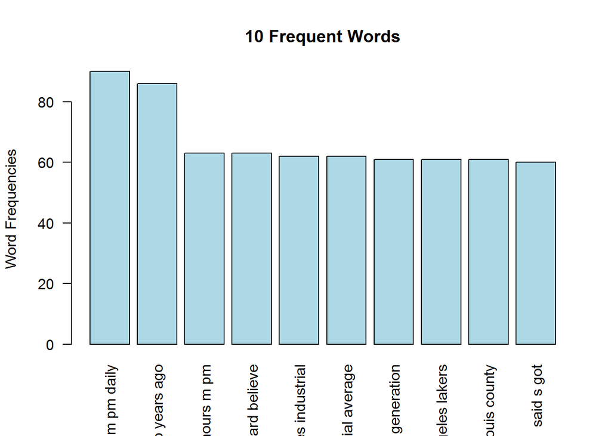

```r
df <-dfit(trigram)
barit(df)
```

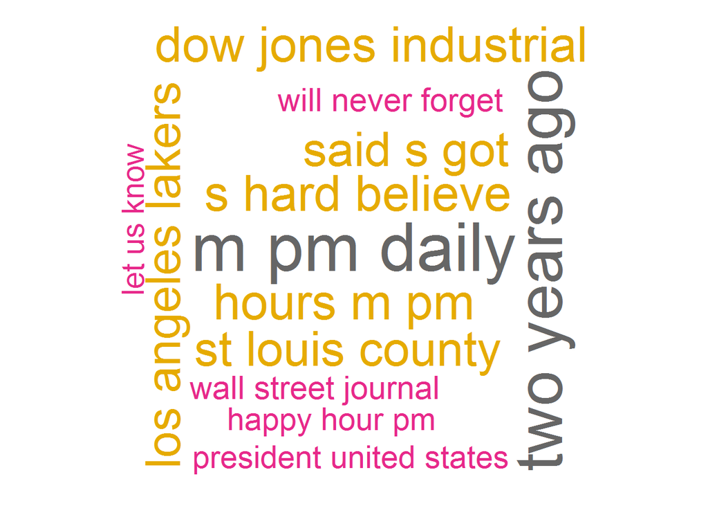

```r
wordit(df)
```

## Next Steps: Building Predictive Model

The exact methodology to produce a model for predictive typing has not been finalized at this point. Planned elements include:

n-gram model: as described in [Task 3], a n-gram model will be built based on the n-gram analysis above.

back-off model: for n-grams not observed in the training material, use back-off model to estimate the conditional probability of a given word.

auto-correction: use edit-distance based matrix to achieve text auto-correction. online model: track and analyze user’s input and selection to improve the model accuracy.

Ideally, multiply predictive models will be constructed and combined in the Shiny application. The models will be ranked based on their accuracy and efficiency, and selectively dispatched in different context.

For the predictive model, the Shiny application will allow the user to enter text. As the input is being provided word by word, it will be evaluated against the predictive model which will determine what word or a set of words (up to 5) are the most likely be the next token the user will input based.